# Eyelink Data Preprocessing

Leon Fonville

December 30, 2019

# Introduction

This document reports a series of preprocessing steps used to classify eyegaze data as fixations or saccades. The chosen processing steps are motivated by selected reading from the literature, some software packages, and available information on processing steps from Tobii. If I failed to cite any relevant sources please let me know!

# Acknowledgements

This document makes use of the dplyr, ggplot, and cowplot packages. Many of the preprocessing steps are inspired by the Tobii documentation by [Olsen, 2012](https://www.tobiipro.com/siteassets/tobii-pro/learn-and-support/analyze/how-do-we-classify-eye-movements/tobii-pro-i-vt-fixation-filter.pdf/?v=2012) The eyegaze velocity thresholding is based on work by [Mould et al., 2012](https://www.sciencedirect.com/science/article/pii/S0042698911004214) as well as the GazePath package by [van RensWoude et al., 2017](https://link.springer.com/article/10.3758%2Fs13428-017-0909-3).

```r
#load libraries
library(dplyr)
library(ggplot2)
library(cowplot)
```

# Summary

```r
#Some housekeeping for the summary table
nTrials = unique(input$trialIdx)
runIdx = unique(input$runIdx)
#exampleSet = c(72, 91, 134, 136) # change later to a random sample
if ((input$trialCode[1]==1 | input$trialCode[1]==2)==TRUE){stimType="Analog Clock"
} else if ((input$trialCode[1]==3 | input$trialCode[1]==4)==TRUE){stimType="Digital Clock"
} else if ((input$trialCode[1]==0)==TRUE){stimType='Fixation Cross'
}else{stimType="Invalid Code"}
if (unique(input$trialCode==1) | unique(input$trialCode==3)){trialType="Perception Trial"
} else if (unique(input$trialCode==2 | unique(input$trialCode==4))){trialType="Imagery Trial"
} else if (unique(input$trialCode[1]==0)){trialType='Not Applicable'
} else{trialType="Invalid Code"}
#prep for reporting trials as subheadings, note the extra line before the closing quotation
subheader <- "### Run %d Trial number %d

"
```

| Tracker: | “Eyelink” |
| --- | --- |
| Participant ID: | pilot |
| Experiment Run: | 1 |
| Number of Trials: | 18 |
| Stimulus: | Analog Clock |
| Trial: | Imagery Trial |

# Remove invalid data

Any implausible eyegaze data will be removed and the Y-axis data will be inverted.

```r
# Calculate an average of eyegaze position across eyes when valid data is available

#THINK ABOUT IF ONLY ONE EYE IS AVAILABLE
validEye.Fun <- function(df, res_x, res_y){

  # Column index contains XY eyegaze data
  xIdx <- grep("X", colnames(df))
  yIdx <- grep("Y", colnames(df))
  tIdx <- grep("timestamp", colnames(df))
  # Remove any eyedata outside of logical range (1920 by 1280)
  df[,xIdx] <- sapply(df[,xIdx], function(x) ifelse(x > res_x | x < 0, NA, x))
  df[,yIdx] <- sapply(df[,yIdx], function(x) ifelse(x > res_y | x < 0, NA, x))

  # Remove "valid" data along one axis if other axis has invalid data
  NAidx <- which(is.na(df[,xIdx])!=is.na(df[,yIdx]))
  df[NAidx, c(xIdx,yIdx,tIdx)]  = NA

  # Flip Y-axis so that the top right (X,Y) = (1,1)
  df$X = df$eyeX
  df$Y = res_y - df$eyeY
  df <- df %>% select(-eyeX, -eyeY)

  # Downsample to a more sensible Hz to clean up the data
  # Trials were 3 seconds and will reduce Hz to 500Hz
  df2 <- df %>% group_by(trialIdx) %>% mutate(bin = ntile(timestamp, (Hz*3)/2)) %>%
    group_by(trialIdx, bin) %>% mutate_at(vars(X, Y, timestamp), mean) %>%
    distinct(X, Y, timestamp, .keep_all = T) %>% ungroup()

  return(df2)
}
input <- validEye.Fun(input, res_x, res_y)
```

Data contains 0 invalid datapoints (0%). After removal of invalid datapoints all data was downsampled to 500 Hz.

# Median Filtering

A sliding window with a windowlength of 5 was applied across the eyegaze data and each datapoint was replaced by the median value of those 5 frames. The smoothed data is shown below in black, with the original data points in red.

```r
medianFilter.Fun <- function(df, win){

  # Find any jumps in data collection
  df <- df %>% group_by(trialIdx) %>% mutate(interval = timestamp - lag(timestamp,1)) %>% ungroup()
  #jumps <- which(scale(df$interval)>3)

  #val = unique(df$interval)
  # Which values are 'a lot' bigger than the smallest value
  #jumps = which(df$interval > quantile(na.omit(val), 0.99))

  #df$jumps = 0
  #df$jumps[jumps] = 1

  # Identify gaps that should be ignored and gaps that can be filled
  # Tobii uses a max gap length of 75ms so we will stick with that
  maxGapL <- (Hz/2) * 0.075
  # Let's loop through trials to find gaps, it will take more time but we won't accidentally group NAs across trials.
  trials = length(nTrials)


  # We'll make a binary vector to indicate long gaps and add it the main dataframe
  gapfill = NULL
  for (t in 1:trials){
    subdf <- df %>% filter(trialIdx==nTrials[t])
    gaps = rle(is.na(subdf$X)) # Since we matched X and Y on NAs it doesn't matter which one we use
    gapdf = data.frame(idx = 1:length(gaps$values),
                       trial = nTrials[t],
                       length = gaps$lengths,
                       values = gaps$values)
    #add column indicating which gaps are too long to fill
    gapdf <- gapdf %>% mutate(omitGap = ifelse(values==TRUE & length >= maxGapL, NA, 1))
    # Append vector
    for (r in 1:nrow(gapdf)){
      gapfill = c(gapfill, rep(gapdf$omitGap[r], gapdf$length[r]))
    }
  }
  df$gapfill = gapfill

  # Fill missing values and smooth data using median filtering with a variable windowsize
  # Median function will return NA when all values are missing so it won't fill large gaps

  windowSlide.Fun <- function(X, window){
    step = round((window-1)/2)

    # If we can't get a symmetrical window we will make the lag longer than the lead
    # So if the windowsize is 10 the value at point i will be the median of
    if((window %% 2) == 0){
      Xlist <- c(lapply(1:step, function(x) lag(X, x)), lapply(1:(step-1), function(x) lead(X, x)))
    } else {Xlist <- c(lapply(1:step, function(x) lag(X, x)), lapply(1:step, function(x) lead(X, x)))}

    # Turn list into a dataframe
    Xdf <- do.call(data.frame, Xlist)

    # Add original timeseries
    Xdf$X <- X

    # Use median filter and return output
    Xf <- apply(Xdf, 1, function(x) median(x, na.rm = T))
    return(Xf)
  }

  # Apply filter to XY coordinates and timestamp
  df <- df %>% group_by(trialIdx) %>%
    mutate(Xf = windowSlide.Fun(X, win),
           Yf = windowSlide.Fun(Y, win),
           frameTime = windowSlide.Fun(timestamp, win))
  df <- df %>% group_by(trialIdx) %>% mutate(frameTime = frameTime - first(frameTime),
                                             frameStep = frameTime-lag(frameTime,1)) %>% ungroup()
  # End by omitting the new values for the large gaps which should remain
  df <- df %>% mutate(Xf = ifelse(gapfill==1, Xf, Xf*gapfill),
                      Yf = ifelse(gapfill==1, Yf, Yf*gapfill ))
  return(df)
}
input <- medianFilter.Fun(input, win)
```

### Run 1 Trial number 76

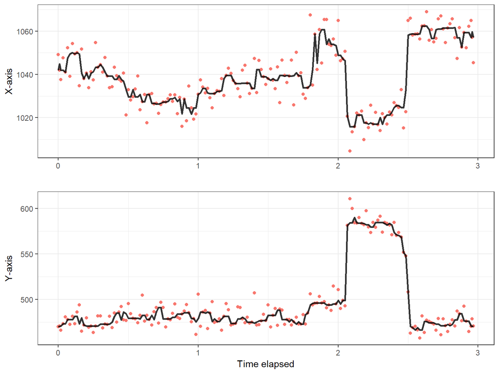

### Run 1 Trial number 78

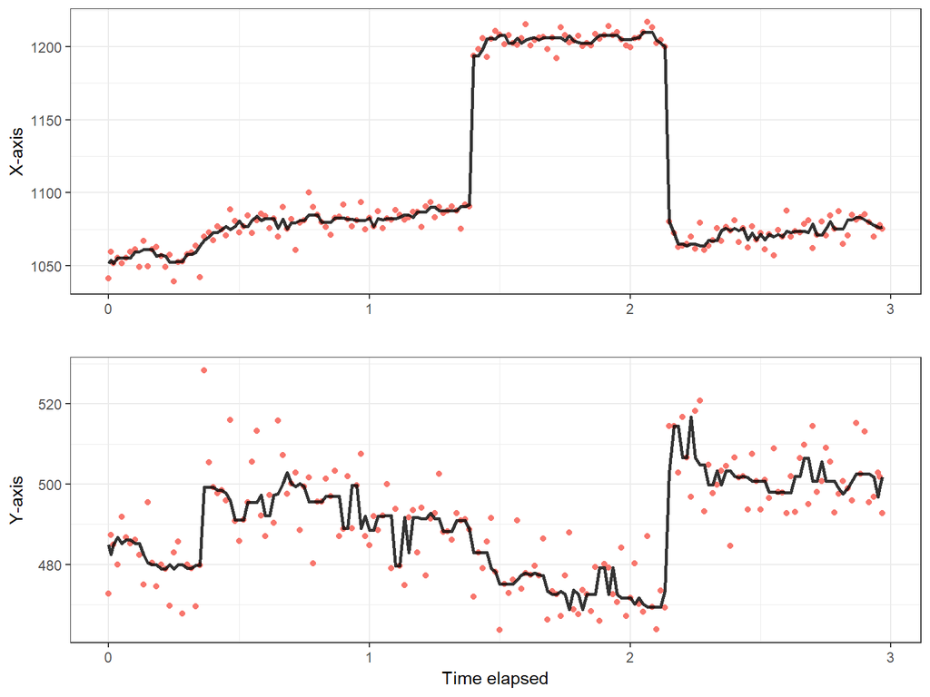

### Run 1 Trial number 79

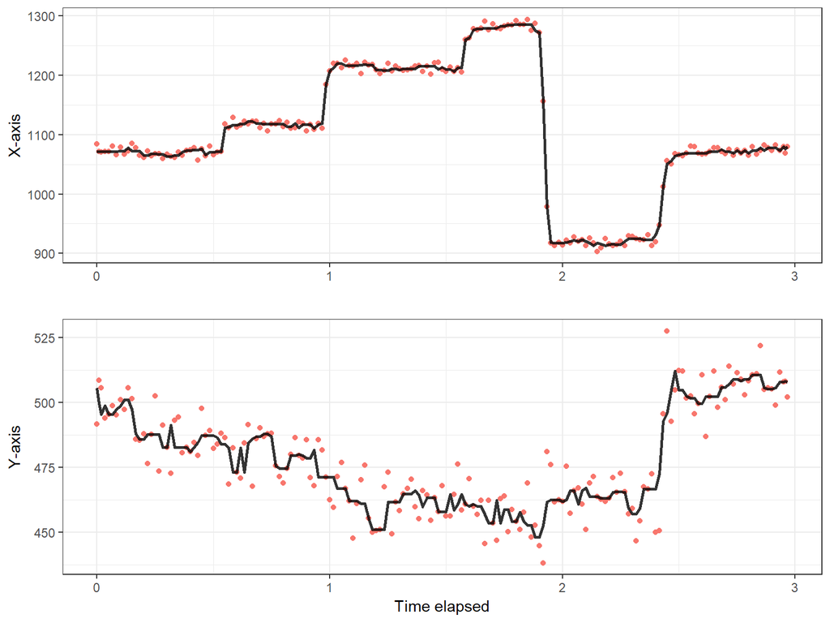

### Run 1 Trial number 85

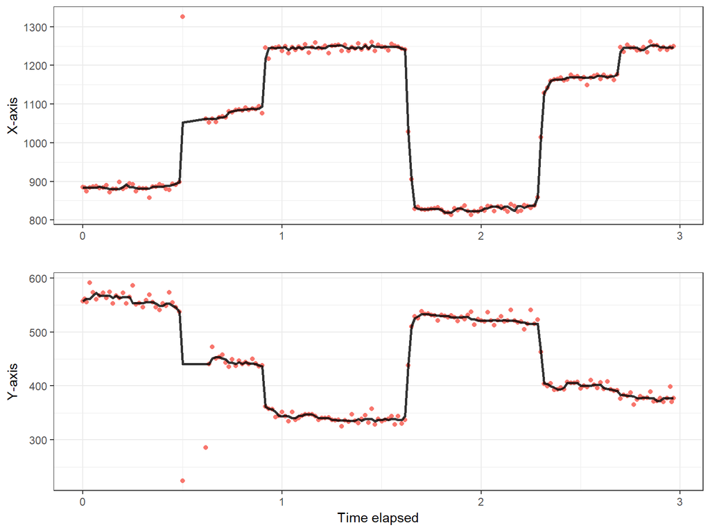

### Run 1 Trial number 90

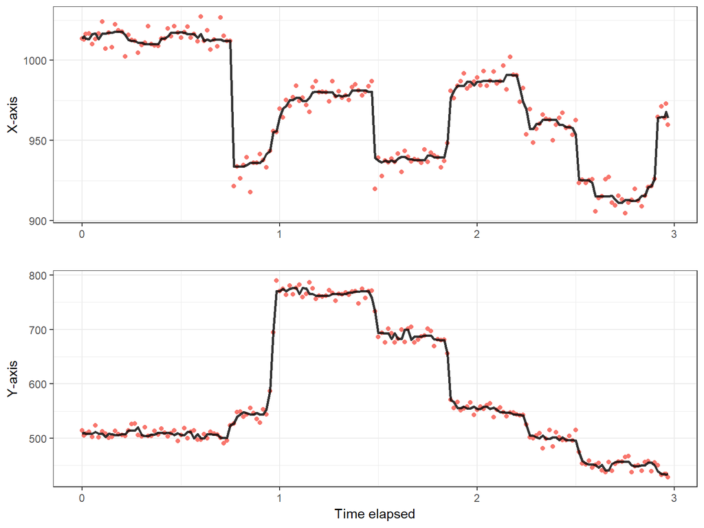

### Run 1 Trial number 98

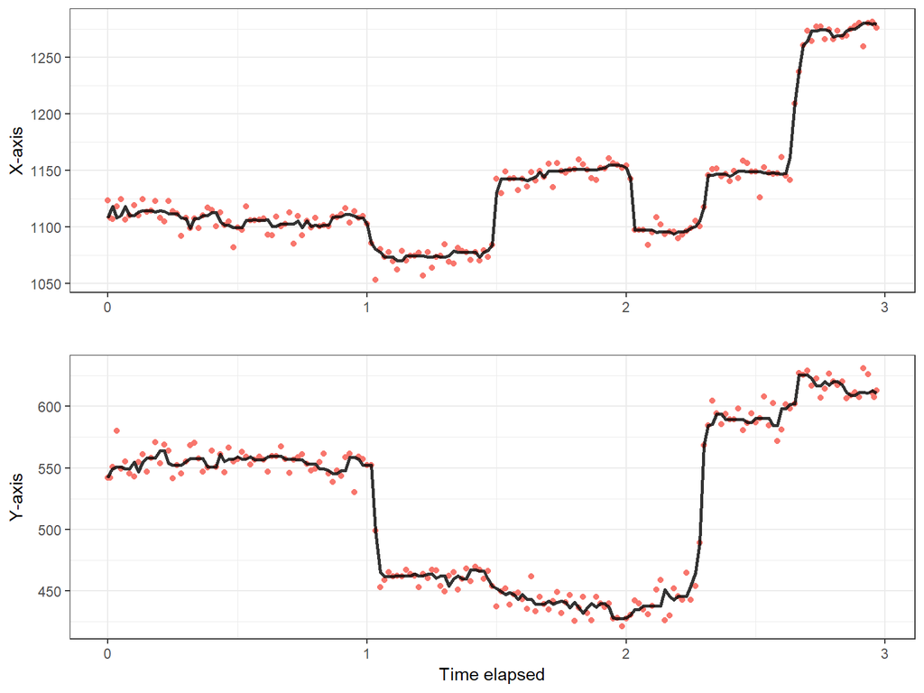

### Run 1 Trial number 101

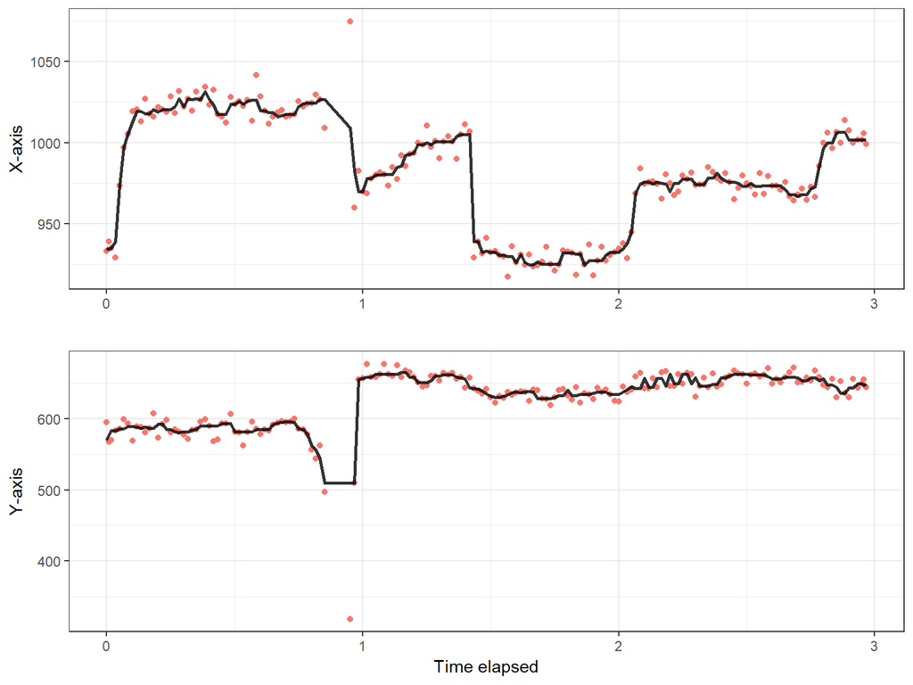

### Run 1 Trial number 103

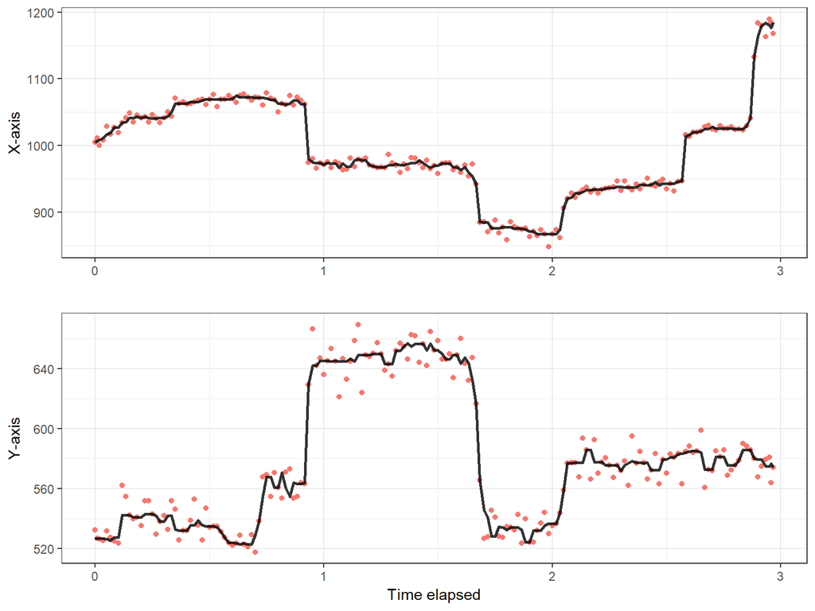

### Run 1 Trial number 106

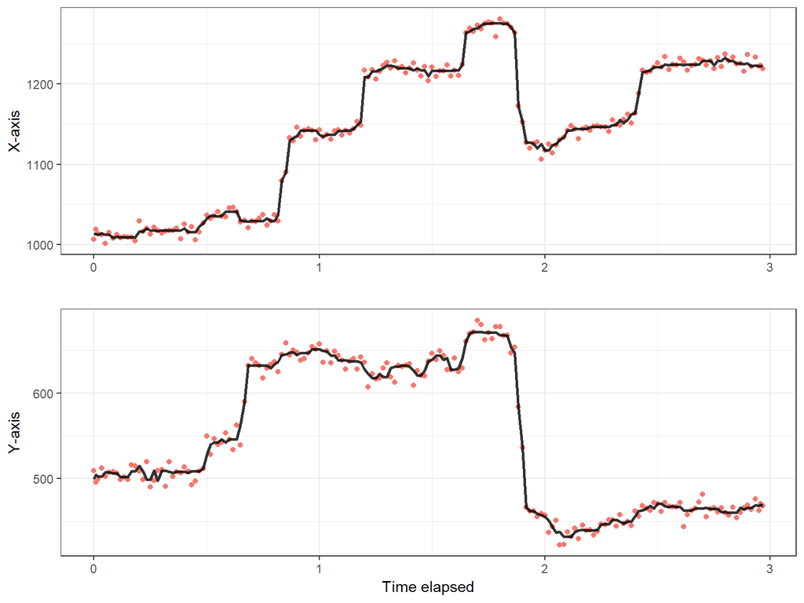

### Run 1 Trial number 109

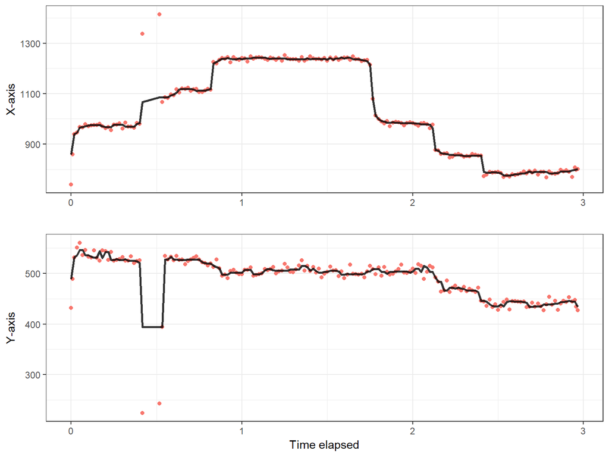

### Run 1 Trial number 110

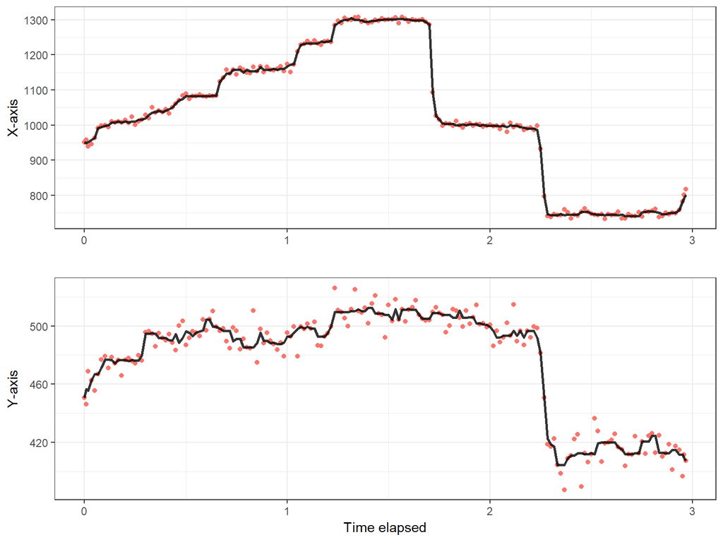

### Run 1 Trial number 112

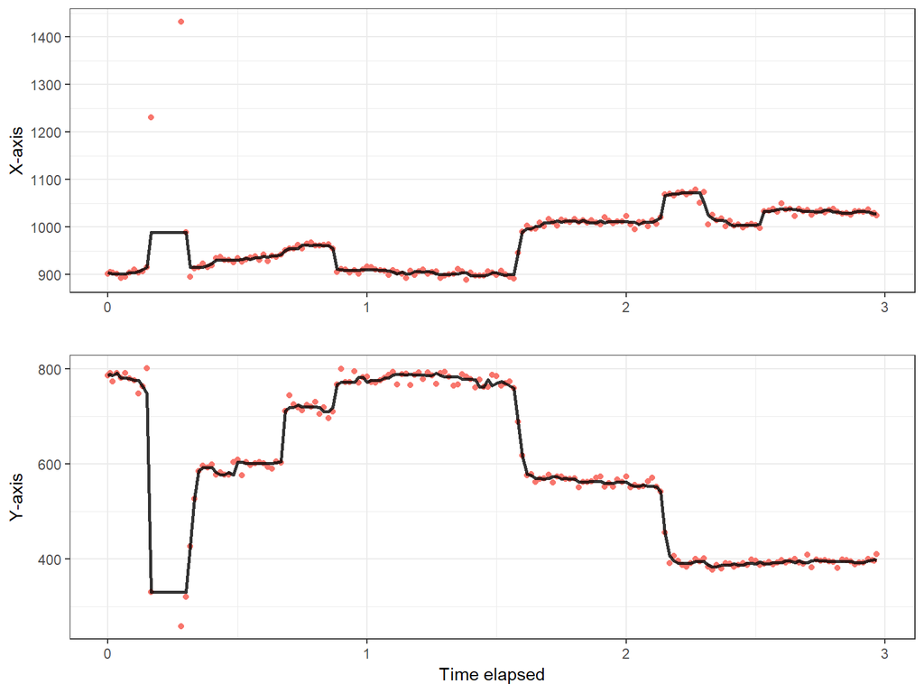

### Run 1 Trial number 125

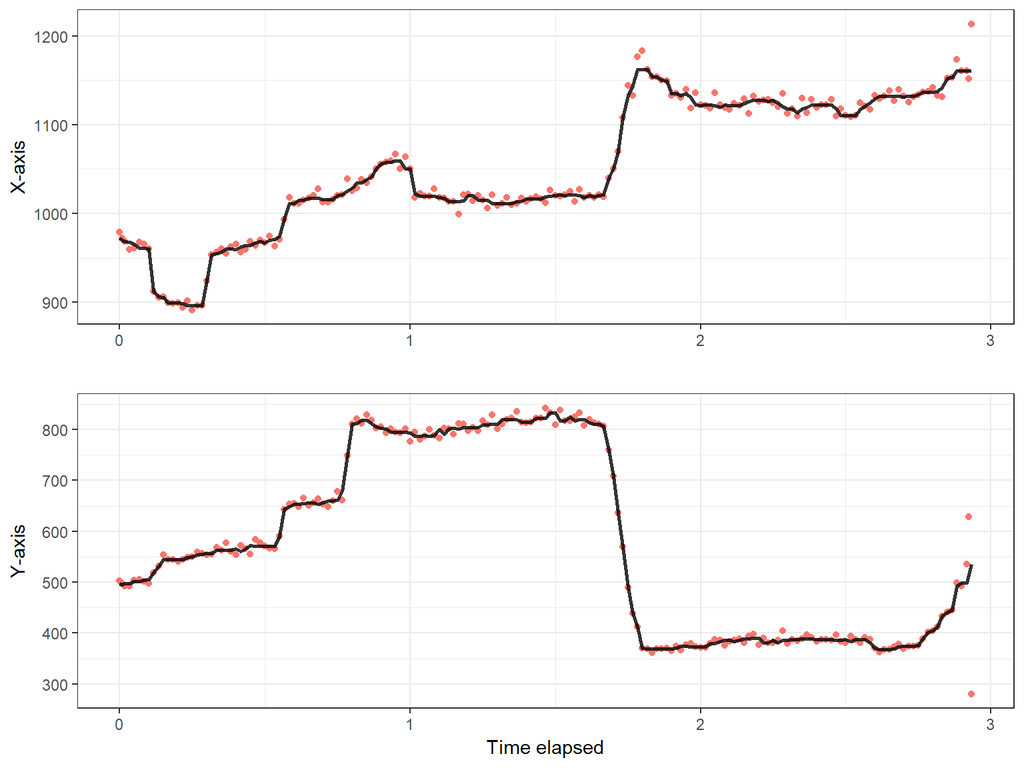

### Run 1 Trial number 127

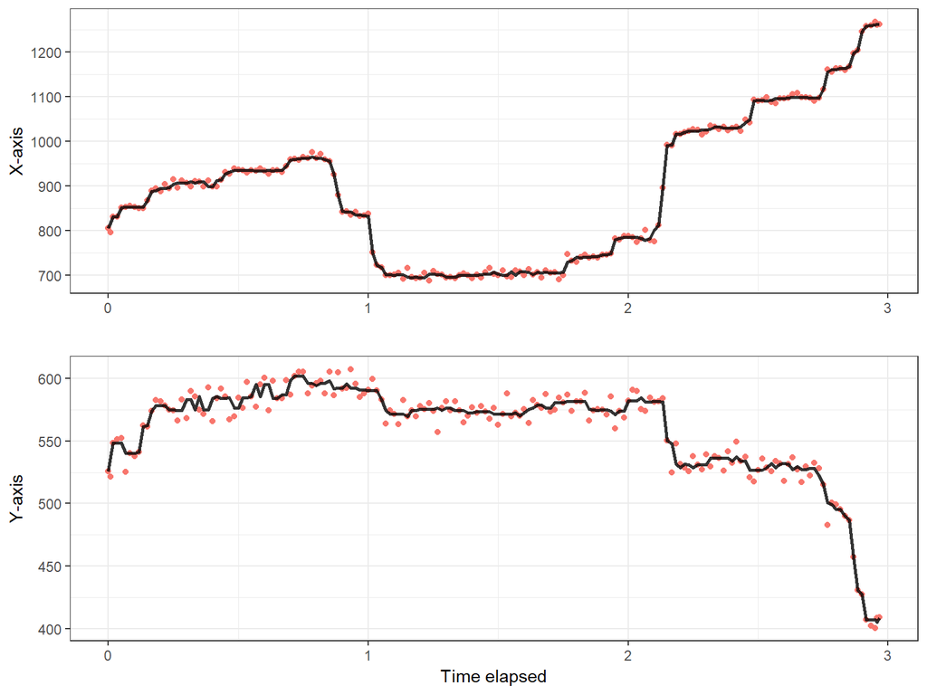

### Run 1 Trial number 129

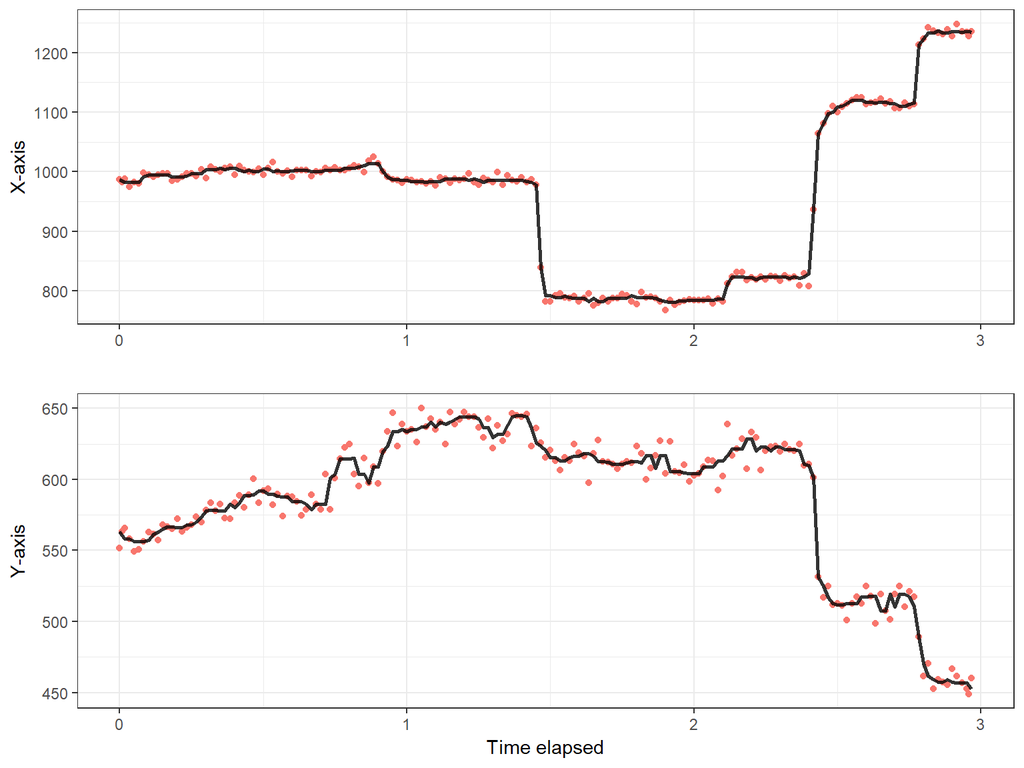

### Run 1 Trial number 130

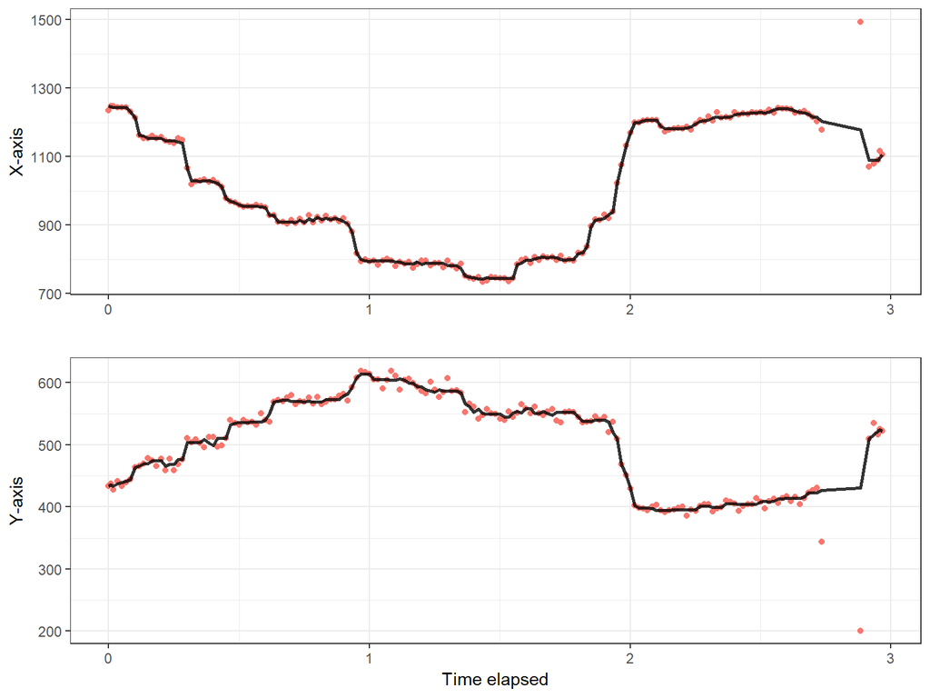

### Run 1 Trial number 131

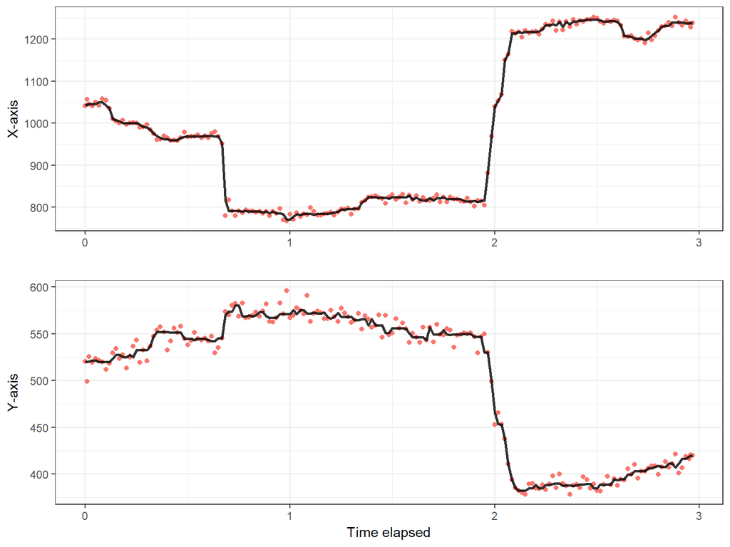

### Run 1 Trial number 135

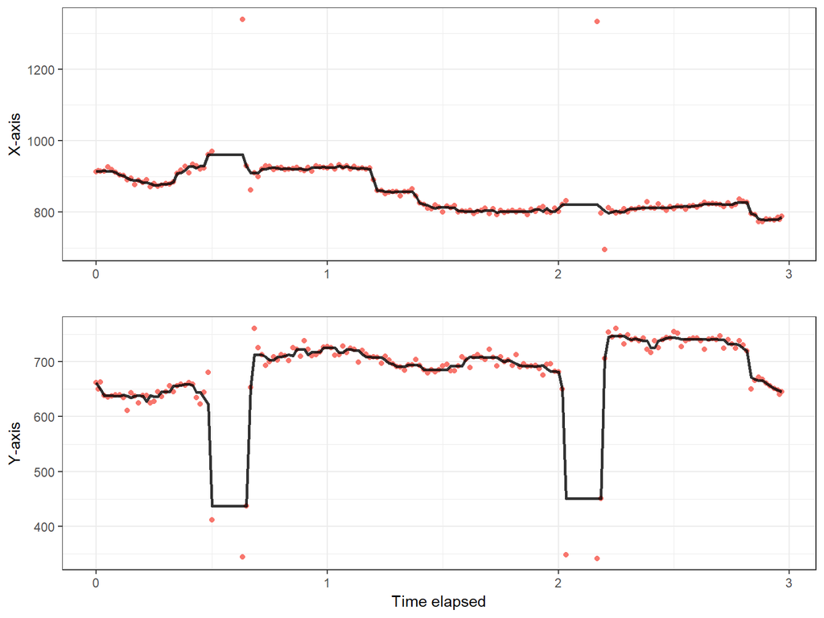

# Velocity Thresholding

We will calculate the velocity at each frame as the distance between the preceding and subsequent datapoint converted into an angle. Distance between pixels will be calculated and the Euclidean distance between points is then calculated in millimeters and is then converted to a visual angle using the recorded distance from the screen. The velocity is reported in degrees per second. Any extreme values (> 99.5th percentile) will be clipped as these most likely represent signal loss.

```r
angleV.Fun <- function(df, scr_x, scr_y, res_x, res_y, distance){

  # Convert pixel distance to angle
  df <- df %>% mutate(Xa = atan((scr_x / 2) / distance) * (180/pi)*2 / res_x * Xf,
                      Ya = atan((scr_y / 2) / distance) * (180/pi)*2 / res_y * Yf) %>%
  # Calculate velocity using distance between angles unless a jump occurred in this window
    # group_by(trialIdx) %>% mutate(AV = ifelse(jumps==0 & lead(jumps,1)==0 & lag(jumps,1)==0,
    #                                           sqrt((lead(Xa,1) - lag(Xa,1))^2 +
    #                                           (lead(Ya,1) - lag(Ya, 1))^2), NA)) %>%
    group_by(trialIdx) %>% mutate(AV = sqrt((lead(Xa,1) - lag(Xa,1))^2 +
                                              (lead(Ya,1) - lag(Ya, 1))^2)) %>%
  # Identify local maxima as points higher than preceding and subsequent points
    mutate(lMax = ifelse((AV > lag(AV, 1) & AV > lead(AV, 1)), 1, 0)) %>%
    ungroup() %>%
  # Clip any extremely large angle values as these most likely represent the tracker losing the eye
    mutate(AVf = ifelse(AV > quantile(na.omit(AV), 0.995), quantile(na.omit(AV), 0.995), AV))
  return(df)
}
input <- angleV.Fun(input, scr_x, scr_y, res_x, res_y, distance)
```

## Find Optimal Velocity Threshold

The next step is to find the speed threshold that optimally separates the distribution of saccades from the distribution of fixational eye movements and noise. We’ll be using local regression models to find the optimum speed threshold and using cross validation to optimise the regression model. Extreme outliers ( > 99.5th percentile) will be clipped before running optimisation.

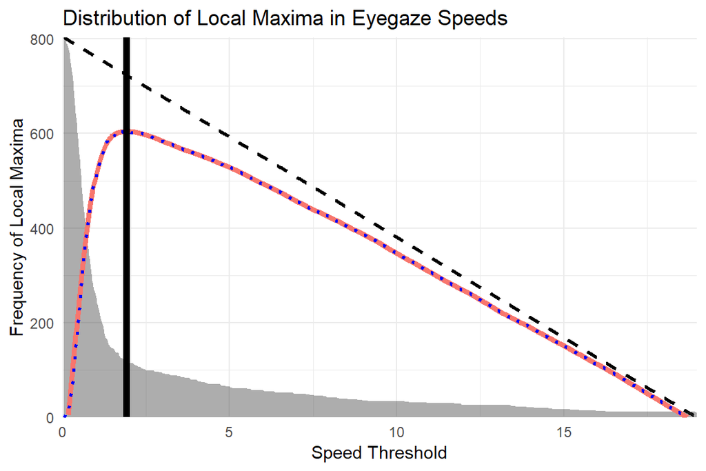

```r
#Requires Angular Velocity (AV) and sampling rate (in Hz) as input
optThresh.Fun <- function(lmV, Hz){
  # Make dataframe of local maxima
  df <- data.frame(idx = 1:Hz,
                   # Speed thresholds range from minimum to maximum recorded velocities in equidistant number of steps
                   thresh = seq(from = min(lmV), to = max(lmV), length.out = Hz),
                   threshCount = NA,
                   # Null represents the frequency of local maxima exceeding the speed threshold across a uniform null distribution
                   nullCount = seq(from = length(lmV), to = 0, length.out = Hz),
                   gap = NA,
                   fit = NA)
  # Get the actual frequency of local maxima exceeding the threshold
  df$threshCount <- sapply(df$thresh, function(x) {length(which(lmV > x))})
  # Compute gap statistic
  df$gap <- df$nullCount - df$threshCount
  # Smooth the gap statistic using a local regression model with optimised smoothing parameter
  # Use k-fold cross validation to find the best smoothing parameter
  k <- 10
  folds <- sample(x = 1:k, size = length(lmV), replace = TRUE)
  hRange <- seq(from = 0.1, to = 0.9, by = 0.01)
  cvMtrx <- matrix(rep(x = NA, times = k * length(hRange)),
                   nrow = length(hRange), ncol = k)
  for(i in 1:length(hRange)) {
    for(j in 1:k) {
      modelFit <- loess(formula = gap ~ log(thresh), data = df[folds != j, ], span = hRange[i])
      modelPredict <- predict(object = modelFit, newdata = df[folds == j, ])
      cvMtrx[i, j] <- mean(abs(df$gap[folds == j] - modelPredict), na.rm = TRUE)
    }
  }
  cvAME <- rowMeans(cvMtrx, na.rm = TRUE)
  hPick <- which.min(cvAME)
  gapFit <- loess(formula = gap ~ log(thresh), data = df, span = hRange[hPick])
  df$fit <- predict(gapFit)
  cvAME_redux <- cvAME
  oldPick <- hPick
  # Check for multiple local maxima in optimal fit
  while (length(which(diff(diff(df$fit)>=0)<0)) > 1){
    # if exists, take the next smallest cvAME and accompanying h value
    cvAME_redux <-  cvAME[-oldPick]
    hPick <- which(cvAME %in% min(cvAME_redux))
    oldPick <- c(oldPick, hPick)
    gapFit <- loess(formula = gap ~ log(thresh), data = df, span = hRange[hPick])
    df$fit <- predict(gapFit)
  }

  # Plot optimal model if need be
  plotDF <- data.frame(x = c(df$thresh, rev(df$thresh)),
                       y = c(df$threshCount, rep(0, Hz)),
                       z = rep(df$nullCount, 2))
  optFit <- ggplot() +
    # Add null line
    geom_line(data = df, aes(x = thresh, y = nullCount), linetype = "dashed", size = 1) +
    # Fill frequency local maxima as shape
    geom_polygon(data = plotDF, aes(x = x, y = y), alpha = 0.4) +
    # Add model fit
    geom_line(data = df, aes(x = thresh, y = fit, color = "red"), size = 1.5) +
    # Add gap line
    geom_line(data = df, aes(x = thresh, y = gap), color = "blue", linetype = "dotted", size = 1) +
    # Add optimal threshold
    geom_vline(xintercept = df$thresh[which.max(df$fit)], size = 2) +
    theme_minimal() +
    scale_x_continuous(limits = c(0, max(df$thresh)), expand = c(0,0)) +
    scale_y_continuous(limits = c(0, max(df$nullCount)), expand = c(0,0)) +
    labs(x = "Speed Threshold", y = "Frequency of Local Maxima") +
    theme(legend.position = "none") + ggtitle("Distribution of Local Maxima in Eyegaze Speeds")

  # Return the data a list
  opt = list()
  opt$cvMatrix <- cvMtrx
  opt$df <- df
  opt$value <- df$thresh[which.max(df$fit)]
  opt$h <- hRange[hPick]
  opt$plot <- optFit
  return(opt)
}
optParam <- input %>% filter(lMax==1) %>% pull(AVf) %>% optThresh.Fun(., Hz) #using clipped angular velocity
optParam$plot #plot the data
```

The observed frequency of local maxima exceeding the speed threshold is depicted in grey. The dashed line depicts the null distribution and the dotted blue line represents the gap between the null and the observed distributions. The red line is a smoothed fit of the gap between the two and the black bar represents the optimal speed threshold for distinguishing fixations from saccades.

The optimal speed threshold for distinguishing fixations from saccades was 1.92

## Optimal Velocity Threshold

Any datapoints exceeding the speed threshold (red dotted line) are labelled as saccades and are depicted in dark blue. Fixations are shown in light blue, but any fixations shorter than 100ms are discarded and are labelled with an intermediate shade.

### Run 1 Trial number 76

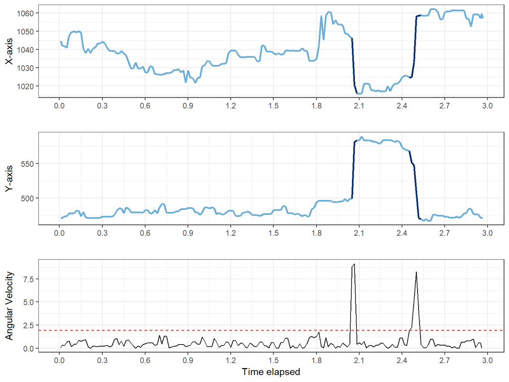

### Run 1 Trial number 78

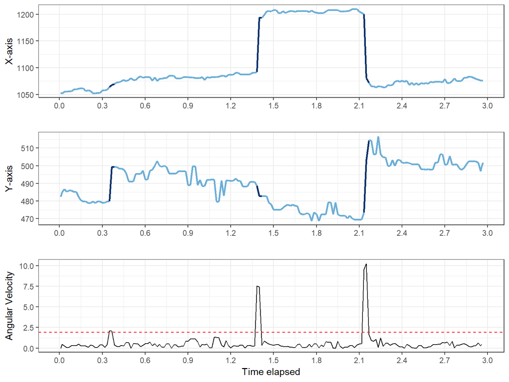

### Run 1 Trial number 79

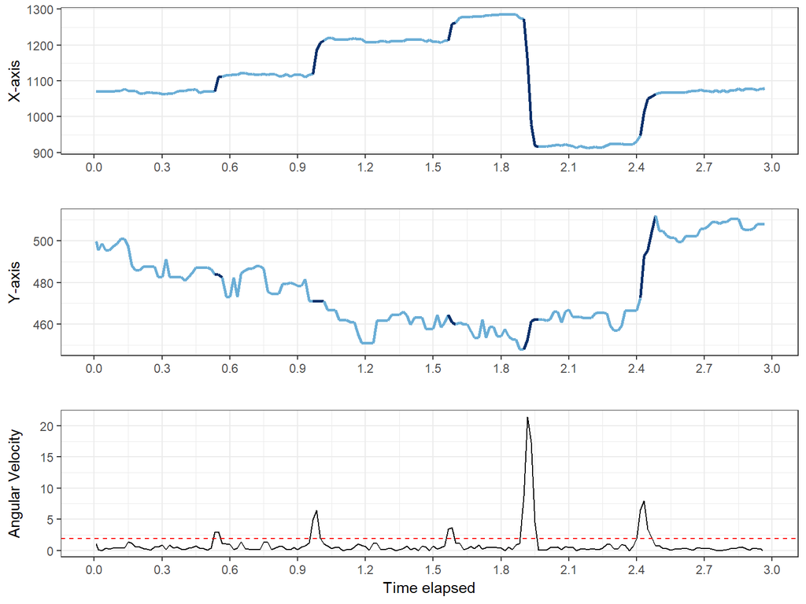

### Run 1 Trial number 85

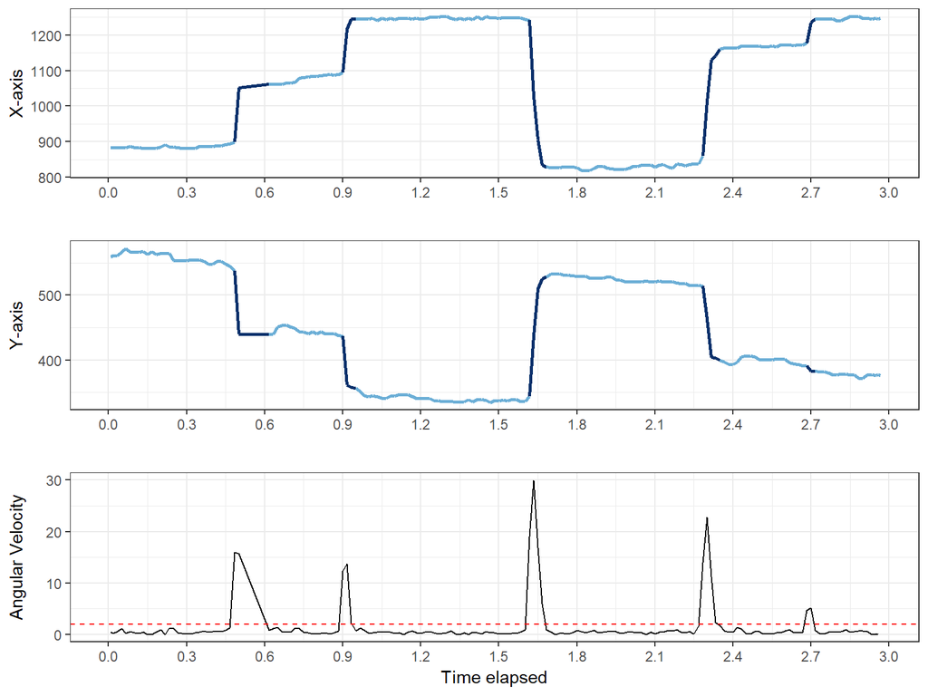

### Run 1 Trial number 90

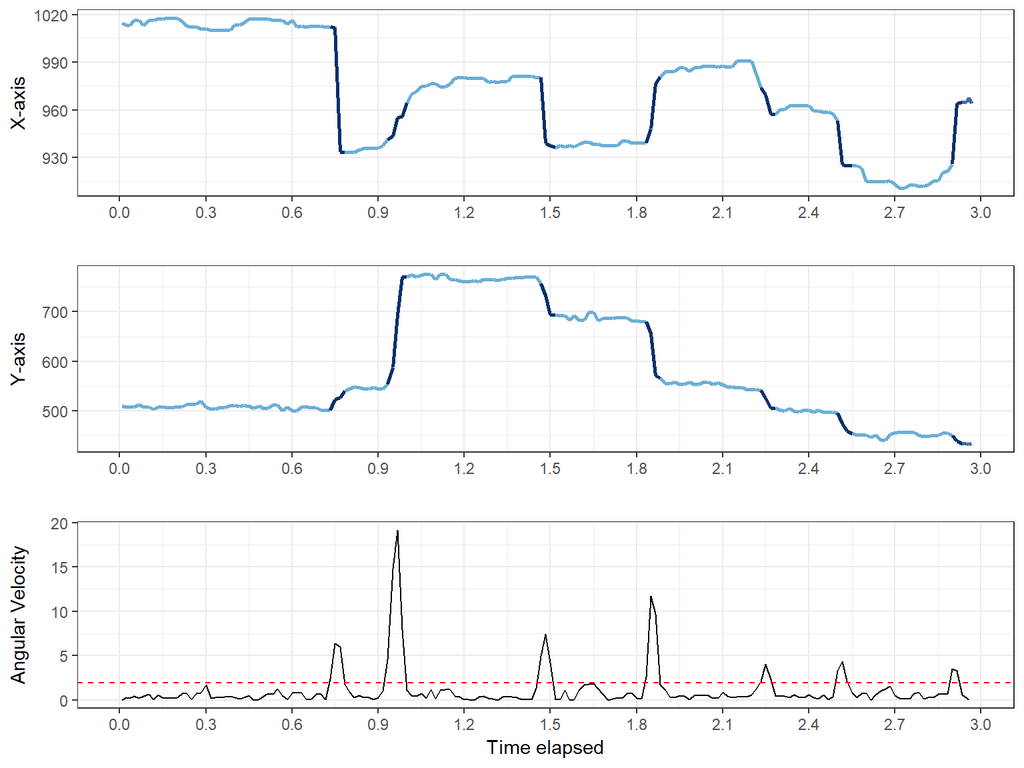

### Run 1 Trial number 98

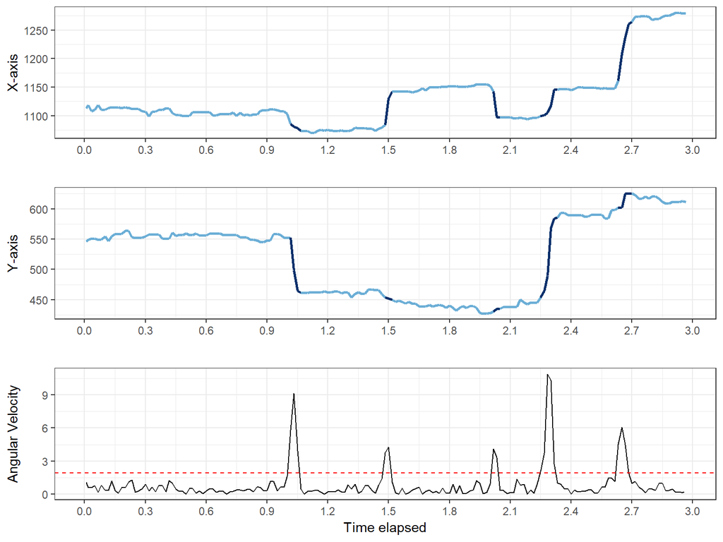

### Run 1 Trial number 101

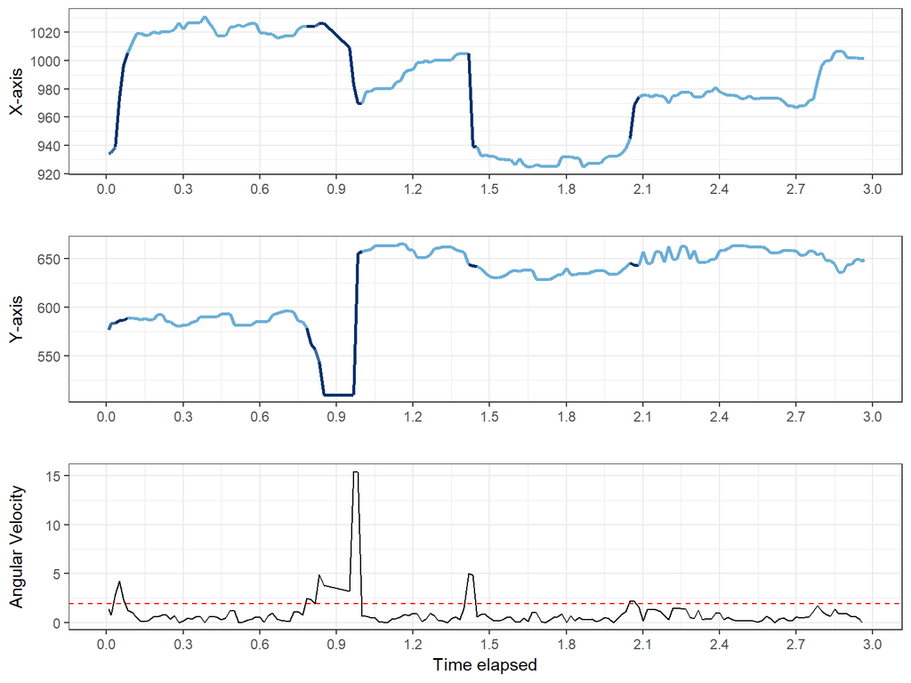

### Run 1 Trial number 103

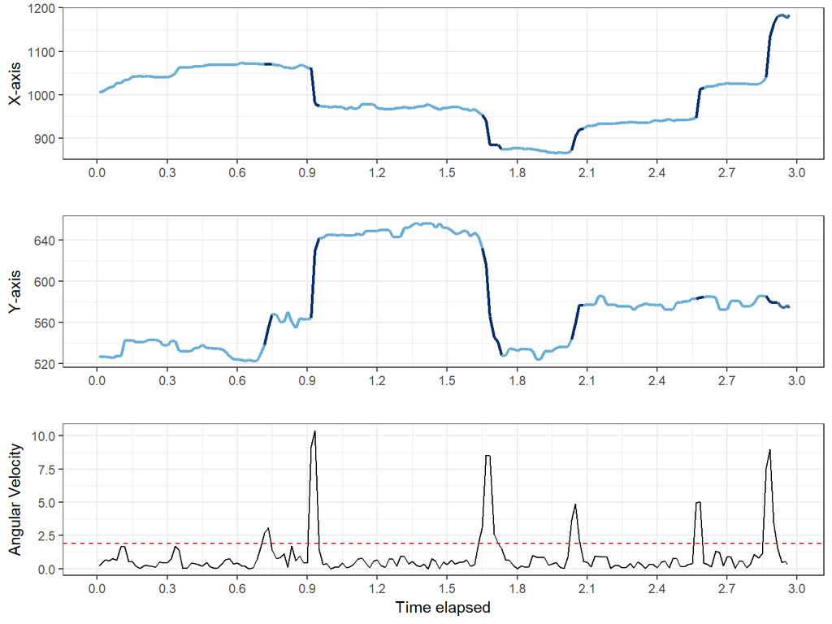

### Run 1 Trial number 106

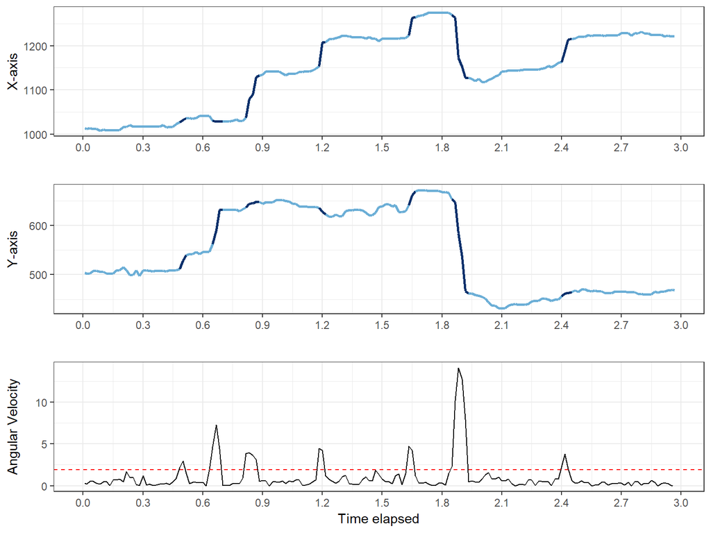

### Run 1 Trial number 109

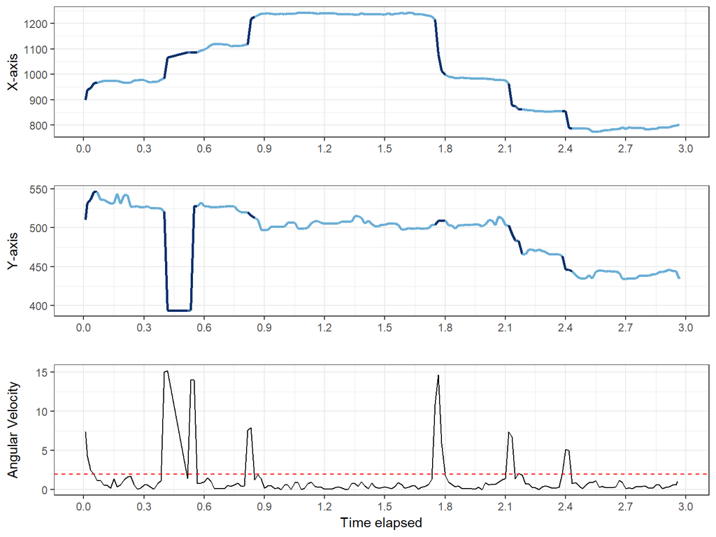

### Run 1 Trial number 110

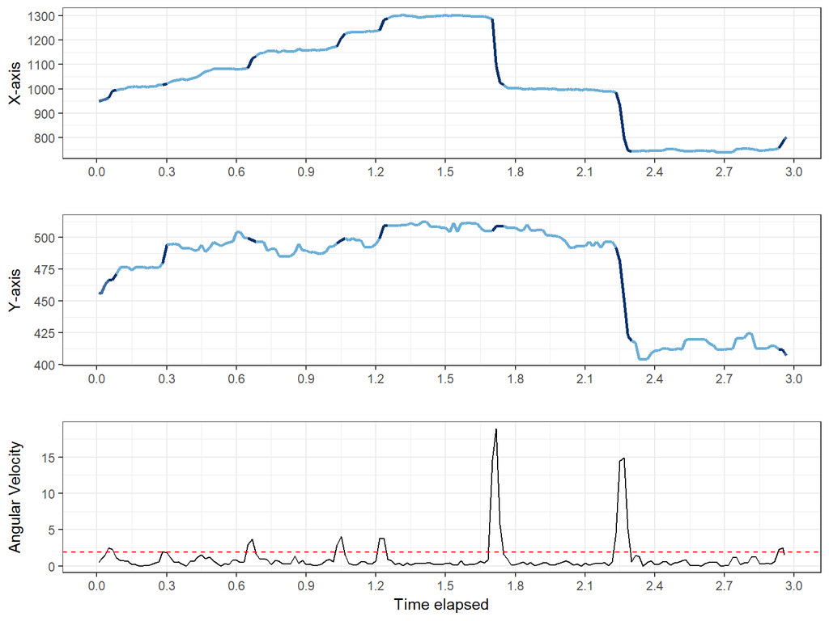

### Run 1 Trial number 112

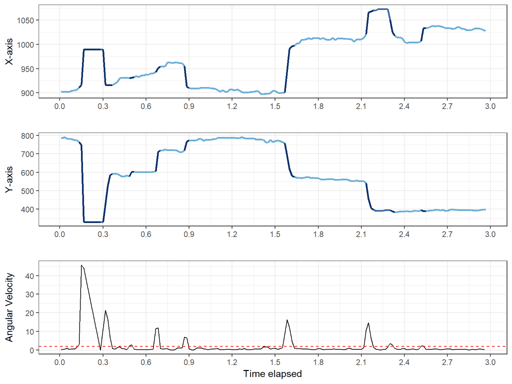